# Mixed-Effects Model for Irradiance Time Above Ek

Angela Richards Donà

11/10/2022

#script for mixed model analysis of Ek and irradiance

Load the various libraries

```r
library(lme4)
library(lmerTest)
library(effects)
library(car)
library(MuMIn)
library (dplyr)
library(emmeans)
library(DHARMa)
library(performance)
library(patchwork)
library(rstatix)
```

```r
#for plots and tables
library(ggplot2)
library(ggpubr)
library(forcats)
library(RColorBrewer)
library(tidyverse)
library(sjPlot)
library(sjmisc)
library(mmtable2)
library(gt)
library(purrr)
library(stringr)
library(tidyr)
```

Load the data

```r
ek_irrad_data <- read.csv("input_data/mean_supersaturation_by_period.csv")
```

Assign run as a factor

```r
ek_irrad_data$Run <- as.factor(ek_irrad_data$Run)
```

Assign temperature as a factor

```r
ek_irrad_data$Temperature <- as.factor(ek_irrad_data$Temp...C.)
```

Assigns treatment as characters from integers then to factors

```r
ek_irrad_data$Treatment <- as.factor(as.character(ek_irrad_data$Treatment))
```

Toggle between the species for output. Use Day 9 for final analysis recent change: removing the very odd ek.1 value of 559.4 in hypnea dataset

```r
hypnea <- subset(ek_irrad_data, Species == "hm")
hypnea$treatment_graph[hypnea$Treatment == 0] <- "1) 35ppt/0.5umol"
hypnea$treatment_graph[hypnea$Treatment == 1] <- "2) 35ppt/14umol"
hypnea$treatment_graph[hypnea$Treatment == 2] <- "3) 28ppt/27umol"
hypnea$treatment_graph[hypnea$Treatment == 3] <- "5) 18ppt/53umol"
hypnea$treatment_graph[hypnea$Treatment == 4] <- "6) 11ppt/80umol"
hypnea$treatment_graph[hypnea$Treatment == 2.5] <- "4) 28ppt/53umol"

ulva <- subset(ek_irrad_data, Species == "ul")
ulva$treatment_graph[ulva$Treatment == 0] <- "1) 35ppt/0.5umol"
ulva$treatment_graph[ulva$Treatment == 1] <- "2) 35ppt/14umol"
ulva$treatment_graph[ulva$Treatment == 2] <- "3) 28ppt/27umol"
ulva$treatment_graph[ulva$Treatment == 3] <- "5) 18ppt/53umol"
ulva$treatment_graph[ulva$Treatment == 4] <- "6) 11ppt/80umol"
ulva$treatment_graph[ulva$Treatment == 2.5] <- "4) 28ppt/53umol"
```

Add growth rate from other dataset to this one and subset by species

```r
growth_rate <- read.csv("/Users/Angela/src/work/limu/algal_growth_photosynthesis/data_input/all_runs_growth_102222.csv")
growth_rate$Species <- as.factor(growth_rate$Species)
growth_rate$treatment <- as.factor(growth_rate$treatment)
```

Subset the growth rate data by Species

```r
gr_ulva <- subset(growth_rate, Species == "Ul")
gr_hypnea <- subset(growth_rate, Species == "Hm" & final.weight != 0.1017)
```

Calculate the growth rate from the data

```r
ulva$growth_rate <- round((gr_ulva$final.weight - gr_ulva$Initial.weight) / gr_ulva$Initial.weight * 100, digits = 2)
hypnea$growth_rate <- round((gr_hypnea$final.weight - gr_hypnea$Initial.weight) / gr_hypnea$Initial.weight * 100, digits = 2)
```

#_______________________ULVA____________________________

Run model without interaction between the treatments and temperature - irradiance_over_ek is in minutes. Take RLC.Order out of the random effects because it is causing problems of singularity. R2 is same with or without (+ (1 | RLC.Order))

```r
ek_irrad_model_ulva <- lmer(formula = supersat_total ~ Treatment + Temperature + (1 | Run) + (1 | Plant.ID), data = ulva)
```

Get an r2 for the model

```r
r.squaredGLMM(ek_irrad_model_ulva)
```

```
##            R2m       R2c
## [1,] 0.3642221 0.8897065
```

Make histograms of data and residuals (first test for mixed model use) and residual plots of the data for ulva

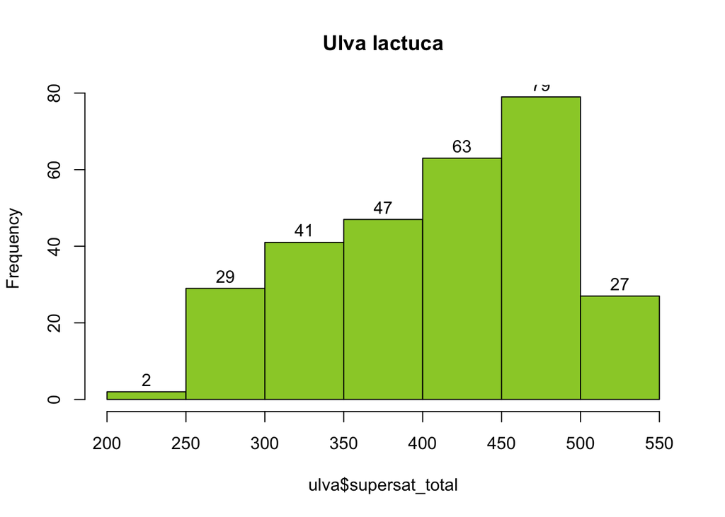

```r
hist(ulva$supersat_total, main = paste("Ulva lactuca"), col = "olivedrab3", labels = TRUE)
```

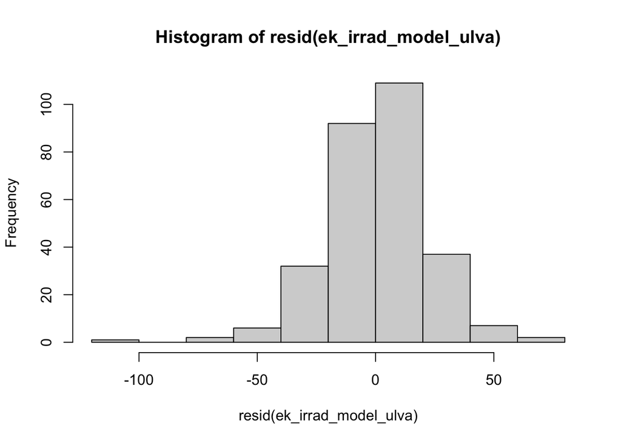

```r
hist(resid(ek_irrad_model_ulva))
```

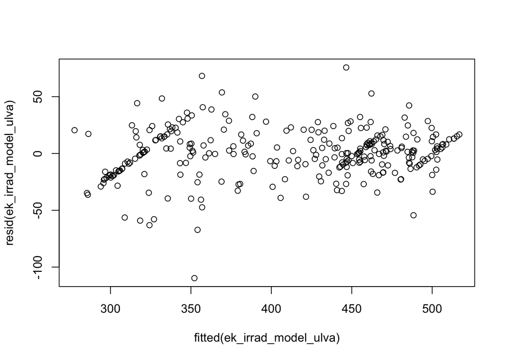

```r
plot(resid(ek_irrad_model_ulva) ~ fitted(ek_irrad_model_ulva))
```

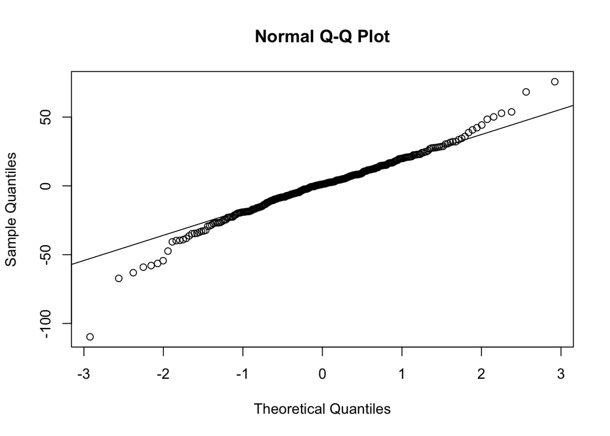

```r
qqnorm(resid(ek_irrad_model_ulva))
qqline(resid(ek_irrad_model_ulva))
```

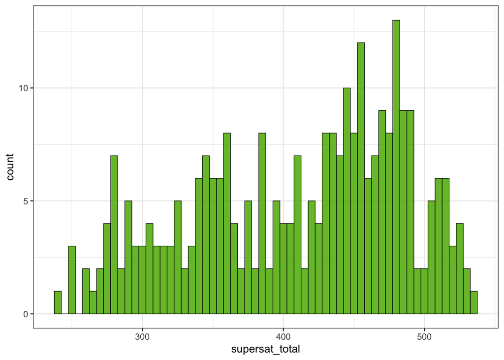

```r
ulva %>% ggplot(aes(supersat_total)) +
        geom_histogram(binwidth=5, fill = "#5BB300", color = "black", size = 0.25, alpha = 0.85) +
        theme_bw()
```

Check the performance of the model and run a summary

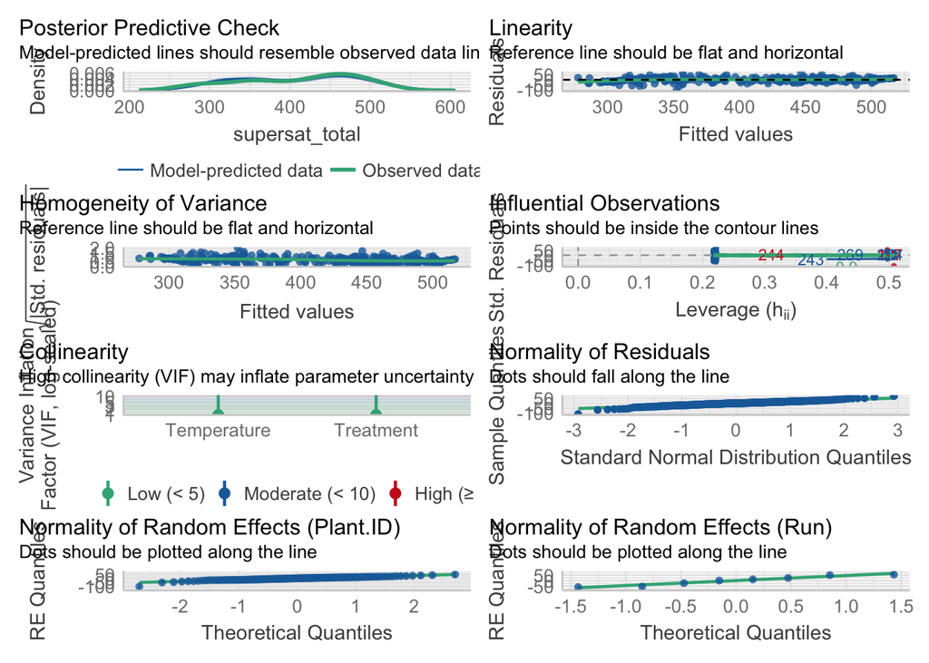

```r
performance::check_model(ek_irrad_model_ulva)
```

```r
summary(ek_irrad_model_ulva)
```

```
## Linear mixed model fit by REML. t-tests use Satterthwaite's method [
## lmerModLmerTest]
## Formula: supersat_total ~ Treatment + Temperature + (1 | Run) + (1 | Plant.ID)
##    Data: ulva
##
## REML criterion at convergence: 2813
##
## Scaled residuals:
##     Min      1Q  Median      3Q     Max
## -4.1222 -0.4370  0.0455  0.4915  2.8439
##
## Random effects:
##  Groups   Name        Variance Std.Dev.
##  Plant.ID (Intercept)  655.3   25.60
##  Run      (Intercept) 2719.5   52.15
##  Residual              708.3   26.61
## Number of obs: 288, groups:  Plant.ID, 144; Run, 8
##
## Fixed effects:
##                Estimate Std. Error        df t value Pr(>|t|)
## (Intercept)    477.5252    37.4668    5.0114  12.745 5.21e-05 ***
## Treatment1     -50.3702    44.2995    4.9966  -1.137   0.3071
## Treatment2     -47.6295    44.2995    4.9966  -1.075   0.3315
## Treatment2.5  -157.9977    64.3119    4.8337  -2.457   0.0592 .
## Treatment3     -80.6781    44.2995    4.9966  -1.821   0.1283
## Treatment4     -88.4096    44.2995    4.9966  -1.996   0.1025
## Temperature27    0.1846     6.8448  115.6816   0.027   0.9785
## Temperature30   -2.3436     6.8448  115.6816  -0.342   0.7327
## ---
## Signif. codes:  0 '***' 0.001 '**' 0.01 '*' 0.05 '.' 0.1 ' ' 1
##
## Correlation of Fixed Effects:
##             (Intr) Trtmn1 Trtmn2 Trt2.5 Trtmn3 Trtmn4 Tmpr27
## Treatment1  -0.836
## Treatment2  -0.836  0.992
## Treatmnt2.5 -0.576  0.487  0.487
## Treatment3  -0.836  0.992  0.992  0.487
## Treatment4  -0.836  0.992  0.992  0.487  0.992
## Temperatr27 -0.091  0.000  0.000  0.000  0.000  0.000
## Temperatr30 -0.091  0.000  0.000  0.000  0.000  0.000  0.500
```

Check for equal variance to determine which ANOVA to use

```r
bartlett.test(supersat_total ~ Treatment, data = ulva)
```

```
##
##  Bartlett test of homogeneity of variances
##
## data:  supersat_total by Treatment
## Bartlett's K-squared = 19.346, df = 5, p-value = 0.001656
```

Run Welch’s ANOVA if not equal variance. Code forces one independent variable at a time. Games Howell Test for pairwise comparison for the only independent variable that was found to have significant results.

```r
welch_anova_treatment_ulva <- oneway.test(supersat_total ~ Treatment, data = ulva, var.equal = FALSE)
welch_anova_treatment_ulva
```

```
##
##  One-way analysis of means (not assuming equal variances)
##
## data:  supersat_total and Treatment
## F = 74.182, num df = 5.00, denom df = 130.53, p-value < 2.2e-16
```

```r
welch_anova_temp_ulva <- oneway.test(supersat_total ~ Temperature, data = ulva, var.equal = FALSE)
welch_anova_temp_ulva
```

```
##
##  One-way analysis of means (not assuming equal variances)
##
## data:  supersat_total and Temperature
## F = 0.16463, num df = 2.00, denom df = 189.68, p-value = 0.8483
```

```r
games_howell_test(ulva, supersat_total ~ Treatment, conf.level = 0.95, detailed = TRUE)
```

```
## # A tibble: 15 × 14
##    .y.    group1 group2    n1    n2 estim…¹ conf.…² conf.h…³    se stati…⁴    df
##  * <chr>  <chr>  <chr>  <int> <int>   <dbl>   <dbl>    <dbl> <dbl>   <dbl> <dbl>
##  1 super… 0      1         48    48  -44.9    -77.4  -12.4    7.88   4.03   85.9
##  2 super… 0      2         48    48  -42.1    -74.8   -9.53   7.91   3.77   85.6
##  3 super… 0      2.5       48    48 -158.    -183.  -133.     6.08  18.4    91.5
##  4 super… 0      3         48    48  -75.2   -108.   -42.2    8.01   6.64   84.8
##  5 super… 0      4         48    48  -82.9   -115.   -50.4    7.89   7.43   85.8
##  6 super… 1      2         48    48    2.74   -34.4   39.9    9.04   0.214  94.0
##  7 super… 1      2.5       48    48 -113.    -144.   -82.2    7.49  10.7    78.2
##  8 super… 1      3         48    48  -30.3    -67.8    7.23   9.12   2.35   93.9
##  9 super… 1      4         48    48  -38.0    -75.1   -0.939  9.02   2.98   94.0
## 10 super… 2      2.5       48    48 -116.    -147.   -84.8    7.52  10.9    77.9
## 11 super… 2      3         48    48  -33.0    -70.7    4.59   9.15   2.55   94.0
## 12 super… 2      4         48    48  -40.8    -78.0   -3.58   9.04   3.19   94.0
## 13 super… 2.5    3         48    48   82.8     51.3  114.     7.62   7.68   77.1
## 14 super… 2.5    4         48    48   75.1     44.1  106.     7.49   7.09   78.2
## 15 super… 3      4         48    48   -7.73   -45.3   29.8    9.13   0.599  93.9
## # … with 3 more variables: p.adj <dbl>, p.adj.signif <chr>, method <chr>, and
## #   abbreviated variable names ¹estimate, ²conf.low, ³conf.high, ⁴statistic
```

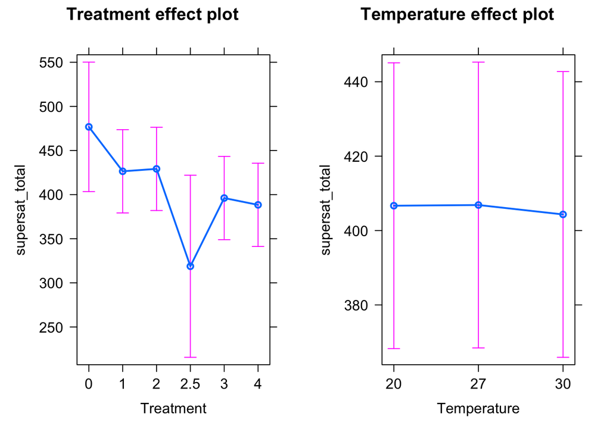

```r
plot(allEffects(ek_irrad_model_ulva))
```

```r
ulva %>% group_by(Treatment) %>% summarise_at(vars(supersat_total), list(mean = mean))
```

```
## # A tibble: 6 × 2
##   Treatment  mean
##   <fct>     <dbl>
## 1 0          477.
## 2 1          432.
## 3 2          435.
## 4 2.5        319.
## 5 3          402.
## 6 4          394.
```

```r
ulva %>% group_by(Run) %>% summarise_at(vars(supersat_total), list(mean = mean))
```

```
## # A tibble: 8 × 2
##   Run    mean
##   <fct> <dbl>
## 1 1      461.
## 2 2      465.
## 3 3      422.
## 4 3.5    352.
## 5 4      349.
## 6 6      452.
## 7 6.5    501.
## 8 9      319.
```

Plot a regression between the photosynthetic independent variables of interest and growth rate

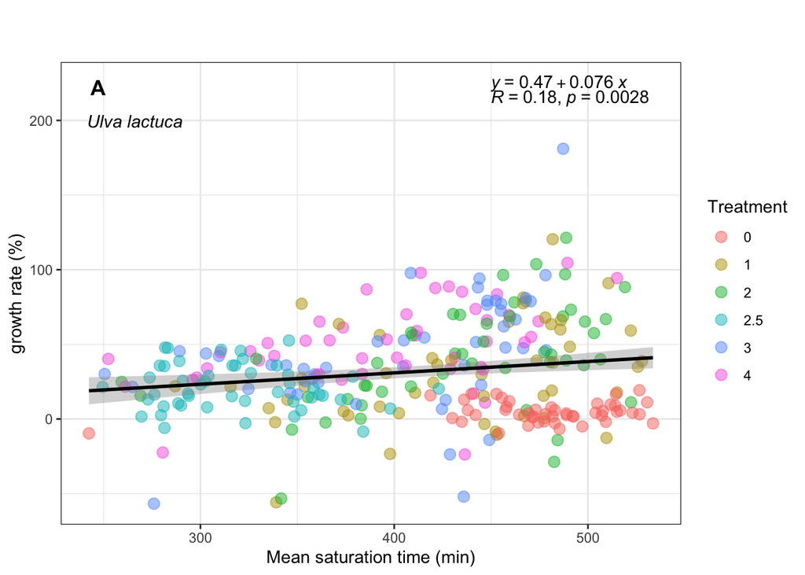

```r
ulva_growth_irrad_ek_graph <- ggplot(ulva, aes(x=supersat_total, y=growth_rate)) +
        geom_point(alpha = 0.5, size = 3, aes(color = Treatment), show.legend = TRUE) +
        geom_smooth(method = "lm", col = "black") + theme_bw() +
        labs(title = "A", subtitle = "Ulva lactuca", x = "Mean saturation time (min)",
             y = "growth rate (%)") + stat_regline_equation(label.x = 450, label.y = 225) +
        stat_cor(label.x = 450, label.y = 215) +
        theme(plot.title = element_text(face = "bold", vjust = -15, hjust = 0.05),
              plot.subtitle = element_text(face = "italic", vjust = -20, hjust = 0.05))
ulva_growth_irrad_ek_graph
```

Plot a histogram in ggplot2

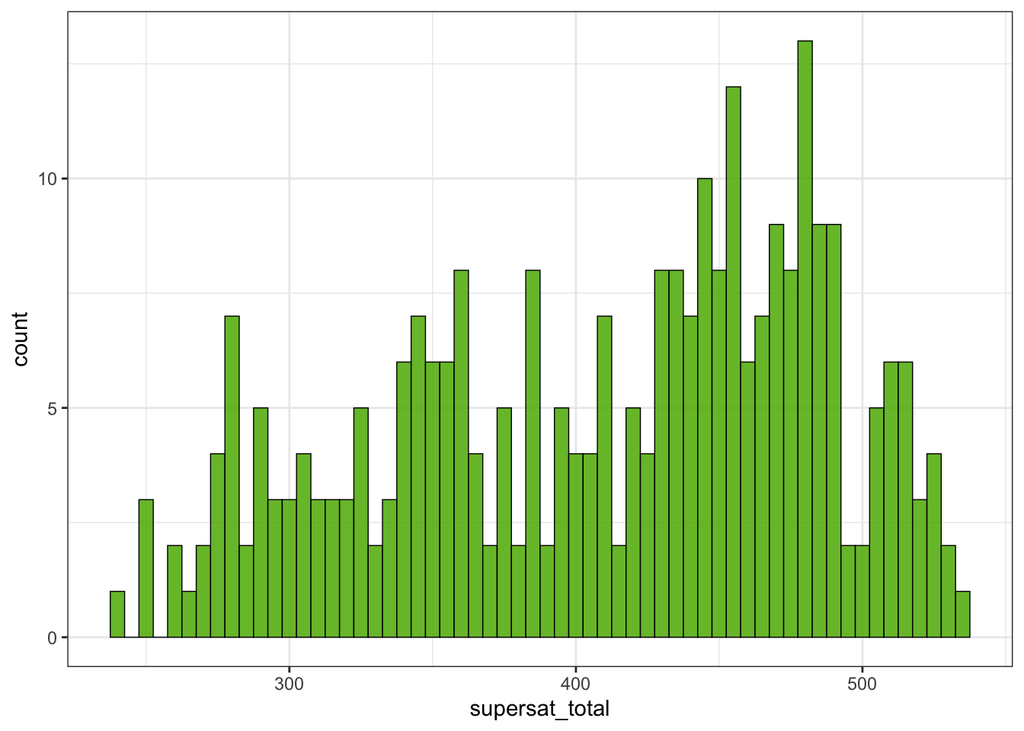

```r
ulva %>% ggplot(aes(supersat_total)) +
        geom_histogram(binwidth=5, fill = "#5BB300", color = "black", size = 0.25, alpha = 0.85) +
        theme_bw()
```

Make a boxplot for publications of the results

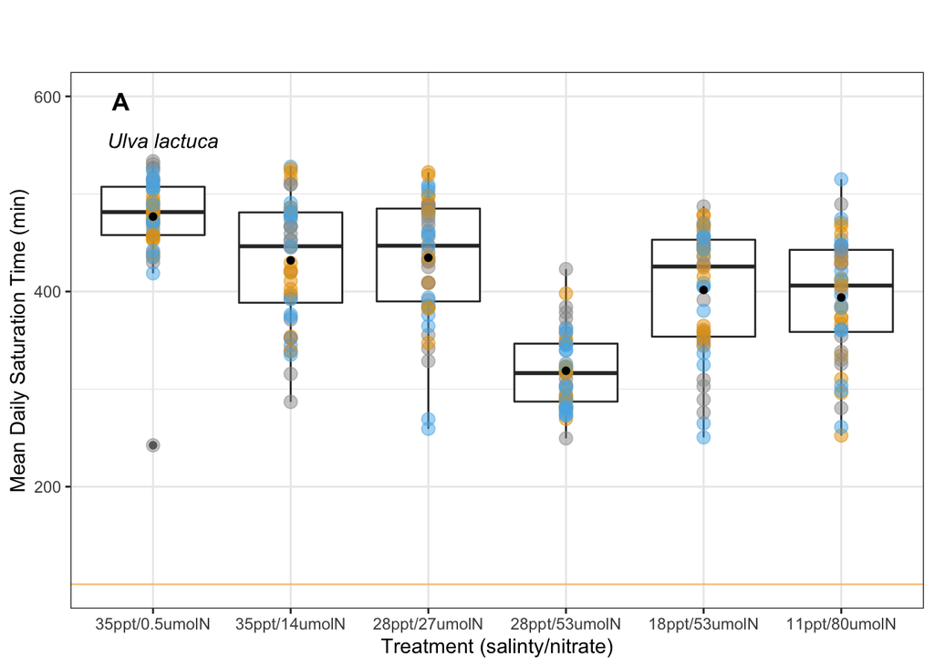

```r
ulva %>% ggplot(aes(treatment_graph, supersat_total)) +
        geom_boxplot(size=0.5) +
        geom_point(alpha = 0.5, size = 3, aes(color = Temperature), show.legend = FALSE) +
        labs(x="Treatment (salinty/nitrate)", y= "Mean Daily Saturation Time (min)", title= "A", subtitle = "Ulva lactuca") +
        scale_x_discrete(labels = c("35ppt/0.5umolN", "35ppt/14umolN", "28ppt/27umolN", "28ppt/53umolN", "18ppt/53umolN", "11ppt/80umolN")) +
        ylim(100, 600) + stat_mean() +
        geom_hline(yintercept=100, color = "orange", size = 0.5, alpha = 0.5) +
        scale_color_manual(values = c("#999999", "#E69F00", "#56B4E9")) +
        theme_bw() +
        theme(legend.position = c(0.90,0.90), plot.title = element_text(face = "bold", vjust = -15, hjust = 0.05),
              plot.subtitle = element_text(face = "italic", vjust = -20, hjust = 0.05))
```

#______________________HYPNEA___________________________

Run model for Hypnea

```r
ek_irrad_model_hypnea <- lmer(formula = supersat_total ~ Treatment + Temperature + (1 | Run) + (1 | Plant.ID), data = hypnea)
```

Get an r2 for the model

```r
r.squaredGLMM(ek_irrad_model_hypnea)
```

```
##            R2m       R2c
## [1,] 0.1460739 0.7597093
```

Make histograms of data and residuals (first test for mixed model use) and residual plots of the data for Hypnea

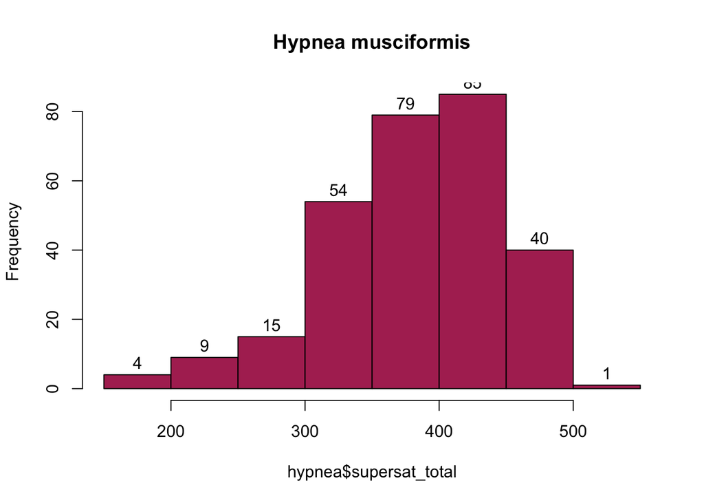

```r
hist(hypnea$supersat_total, main = paste("Hypnea musciformis"), col = "maroon", labels = TRUE)
```

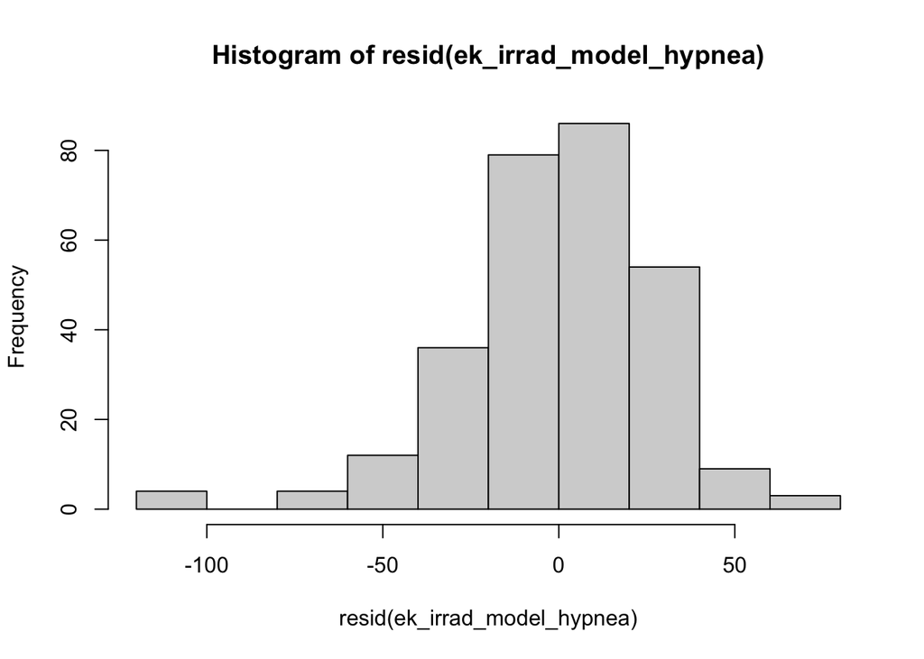

```r
hist(resid(ek_irrad_model_hypnea))
```

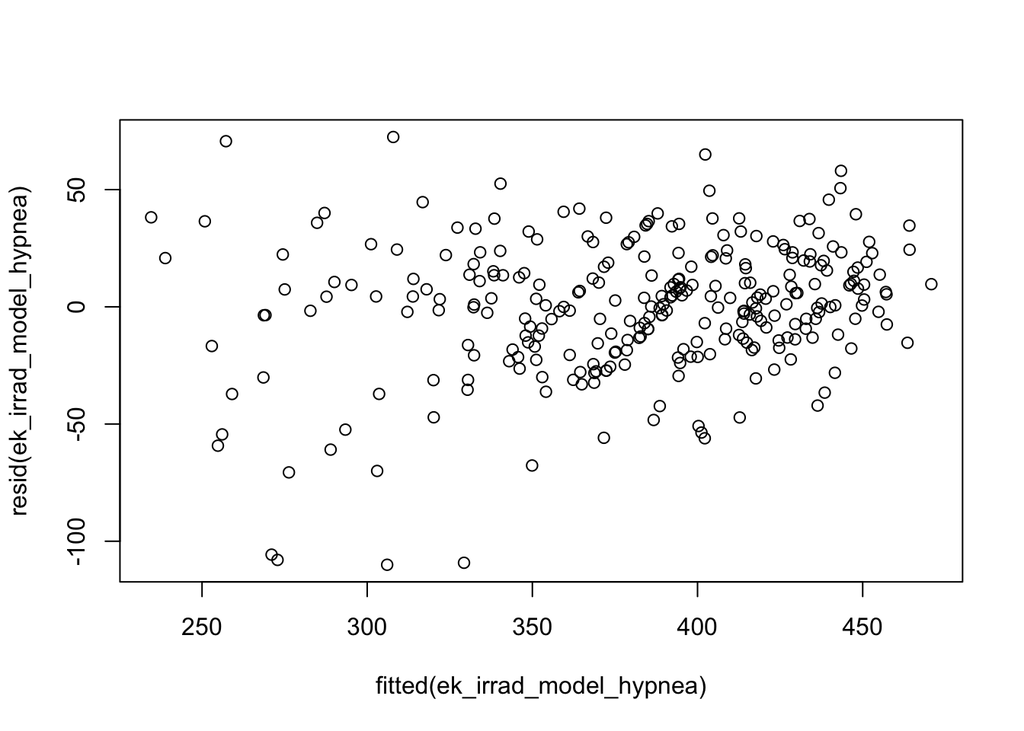

```r
plot(resid(ek_irrad_model_hypnea) ~ fitted(ek_irrad_model_hypnea))
```

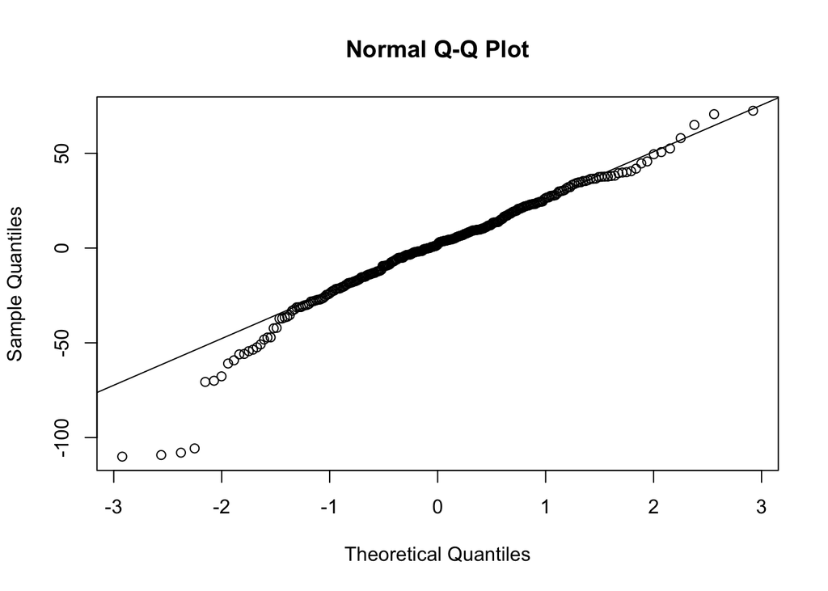

```r
qqnorm(resid(ek_irrad_model_hypnea))
qqline(resid(ek_irrad_model_hypnea))
```

Plot a histogram in ggplot

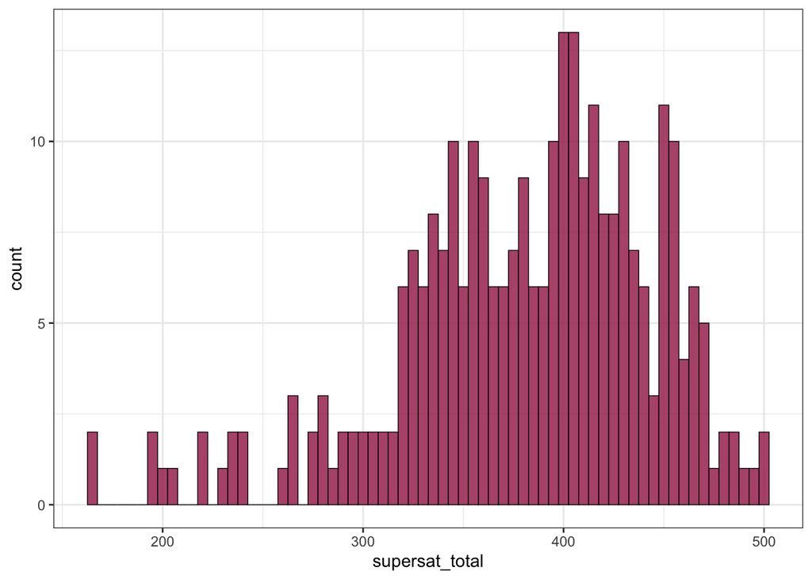

```r
hypnea %>% ggplot(aes(supersat_total)) +
        geom_histogram(binwidth=5, fill = "#a8325e", color = "black", size = 0.25, alpha = 0.85) +
        theme_bw()
```

Check the performance of the model

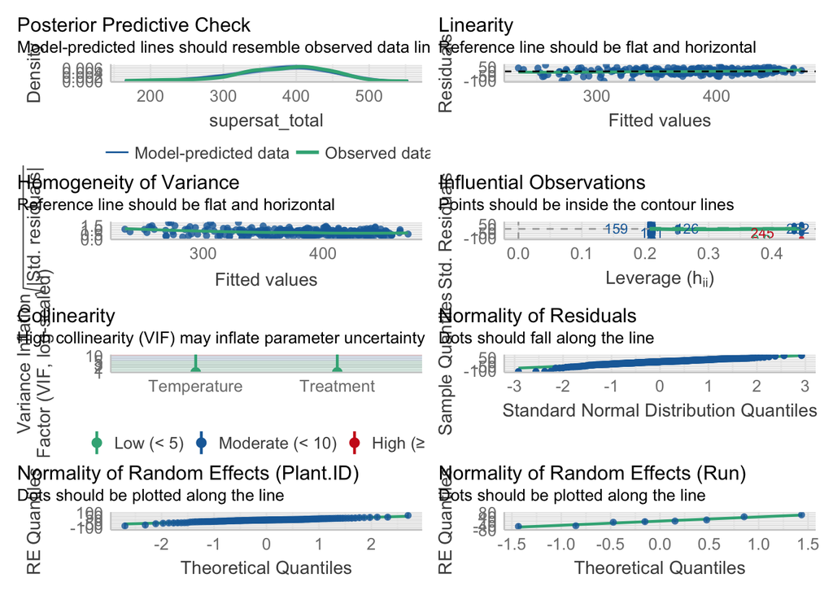

```r
performance::check_model(ek_irrad_model_hypnea)
```

Run a summary of the model

```r
summary(ek_irrad_model_hypnea)
```

```
## Linear mixed model fit by REML. t-tests use Satterthwaite's method [
## lmerModLmerTest]
## Formula: supersat_total ~ Treatment + Temperature + (1 | Run) + (1 | Plant.ID)
##    Data: hypnea
##
## REML criterion at convergence: 2904.6
##
## Scaled residuals:
##     Min      1Q  Median      3Q     Max
## -3.3115 -0.4540  0.0553  0.5465  2.1801
##
## Random effects:
##  Groups   Name        Variance Std.Dev.
##  Plant.ID (Intercept)  787.4   28.06
##  Run      (Intercept) 2032.5   45.08
##  Residual             1104.2   33.23
## Number of obs: 287, groups:  Plant.ID, 144; Run, 8
##
## Fixed effects:
##               Estimate Std. Error      df t value Pr(>|t|)
## (Intercept)    396.535     32.811   5.043  12.086 6.47e-05 ***
## Treatment1     -49.539     38.782   5.021  -1.277 0.257345
## Treatment2     -35.766     38.782   5.021  -0.922 0.398558
## Treatment2.5   -37.009     55.925   4.729  -0.662 0.538991
## Treatment3     -51.386     38.782   5.021  -1.325 0.242263
## Treatment4     -69.747     38.789   5.025  -1.798 0.131789
## Temperature27   29.394      7.910 131.267   3.716 0.000299 ***
## Temperature30   32.267      7.915 131.714   4.077 7.86e-05 ***
## ---
## Signif. codes:  0 '***' 0.001 '**' 0.01 '*' 0.05 '.' 0.1 ' ' 1
##
## Correlation of Fixed Effects:
##             (Intr) Trtmn1 Trtmn2 Trt2.5 Trtmn3 Trtmn4 Tmpr27
## Treatment1  -0.830
## Treatment2  -0.830  0.985
## Treatmnt2.5 -0.575  0.487  0.487
## Treatment3  -0.830  0.985  0.985  0.487
## Treatment4  -0.830  0.985  0.985  0.487  0.985
## Temperatr27 -0.121  0.000  0.000  0.000  0.000  0.000
## Temperatr30 -0.121  0.000  0.000  0.000  0.000  0.001  0.500
```

Check for equal variance

```r
bartlett.test(supersat_total ~ Treatment, data = hypnea)
```

```
##
##  Bartlett test of homogeneity of variances
##
## data:  supersat_total by Treatment
## Bartlett's K-squared = 50.954, df = 5, p-value = 8.84e-10
```

```r
welch_anova_treatment <- oneway.test(supersat_total ~ Treatment, data = hypnea, var.equal = FALSE)
welch_anova_treatment
```

```
##
##  One-way analysis of means (not assuming equal variances)
##
## data:  supersat_total and Treatment
## F = 7.4774, num df = 5.00, denom df = 127.19, p-value = 3.509e-06
```

```r
welch_anova_temp <- oneway.test(supersat_total ~ Temperature, data = hypnea, var.equal = FALSE)
welch_anova_temp
```

```
##
##  One-way analysis of means (not assuming equal variances)
##
## data:  supersat_total and Temperature
## F = 11.458, num df = 2.00, denom df = 184.95, p-value = 2.036e-05
```

```r
games_howell_test(hypnea, supersat_total ~ Treatment, conf.level = 0.95, detailed = TRUE)
```

```
## # A tibble: 15 × 14
##    .y.     group1 group2    n1    n2 estim…¹ conf.…² conf.…³    se stati…⁴    df
##  * <chr>   <chr>  <chr>  <int> <int>   <dbl>   <dbl>   <dbl> <dbl>   <dbl> <dbl>
##  1 supers… 0      1         48    48  -42.7    -81.9   -3.53  9.47   3.19   75.1
##  2 supers… 0      2         48    48  -28.9    -63.5    5.60  8.37   2.44   83.1
##  3 supers… 0      2.5       48    48  -37.0    -60.0  -14.0   5.56   4.70   78.4
##  4 supers… 0      3         48    48  -44.6    -79.3   -9.82  8.42   3.74   82.8
##  5 supers… 0      4         48    47  -62.0    -94.5  -29.6   7.87   5.57   85.9
##  6 supers… 1      2         48    48   13.8    -30.4   57.9  10.7    0.908  91.3
##  7 supers… 1      2.5       48    48    5.71   -30.6   42.0   8.71   0.463  58.8
##  8 supers… 1      3         48    48   -1.85   -46.2   42.5  10.8    0.121  91.6
##  9 supers… 1      4         48    47  -19.3    -61.9   23.3  10.3    1.32   87.6
## 10 supers… 2      2.5       48    48   -8.07   -39.2   23.1   7.50   0.760  63.3
## 11 supers… 2      3         48    48  -15.6    -56.0   24.7   9.81   1.13   94.0
## 12 supers… 2      4         48    47  -33.1    -71.5    5.37  9.34   2.50   92.4
## 13 supers… 2.5    3         48    48   -7.55   -39.0   23.8   7.55   0.707  63.1
## 14 supers… 2.5    4         48    47  -25.0    -53.8    3.79  6.94   2.55   65.1
## 15 supers… 3      4         48    47  -17.5    -56.1   21.2   9.38   1.32   92.2
## # … with 3 more variables: p.adj <dbl>, p.adj.signif <chr>, method <chr>, and
## #   abbreviated variable names ¹estimate, ²conf.low, ³conf.high, ⁴statistic
```

```r
games_howell_test(hypnea, supersat_total ~ Temperature, conf.level = 0.95, detailed = TRUE)
```

```
## # A tibble: 3 × 14
##   .y.      group1 group2    n1    n2 estim…¹ conf.…² conf.…³    se stati…⁴    df
## * <chr>    <chr>  <chr>  <int> <int>   <dbl>   <dbl>   <dbl> <dbl>   <dbl> <dbl>
## 1 supersa… 20     27        96    96   38.3     16.4    60.2  6.54   4.14   165.
## 2 supersa… 20     30        96    95   43.3     21.0    65.6  6.67   4.59   170.
## 3 supersa… 27     30        96    95    4.96   -12.7    22.6  5.27   0.665  188.
## # … with 3 more variables: p.adj <dbl>, p.adj.signif <chr>, method <chr>, and
## #   abbreviated variable names ¹estimate, ²conf.low, ³conf.high, ⁴statistic
```

Plot results for basic output

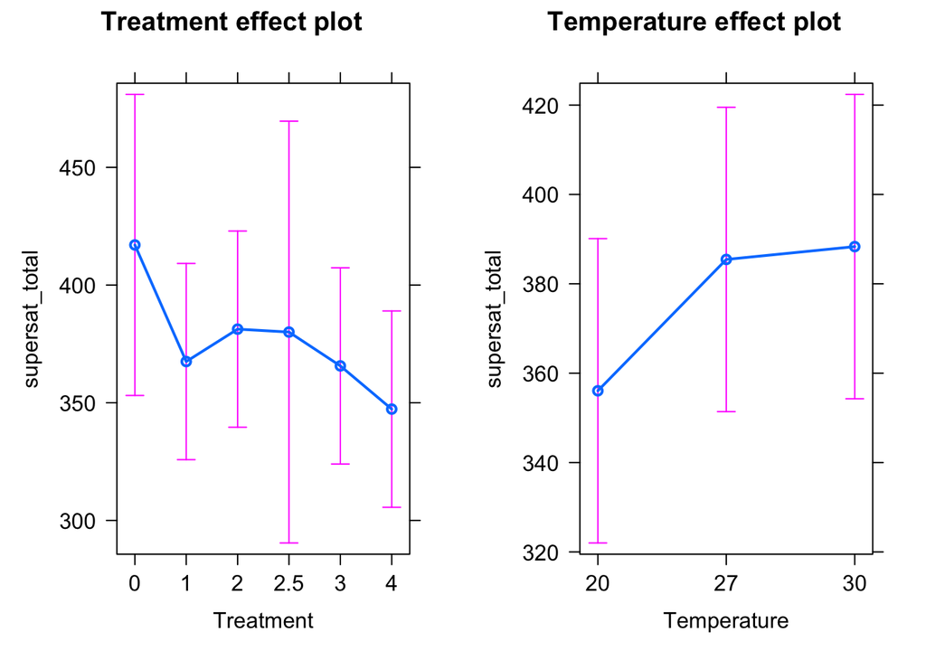

```r
plot(allEffects(ek_irrad_model_hypnea))
```

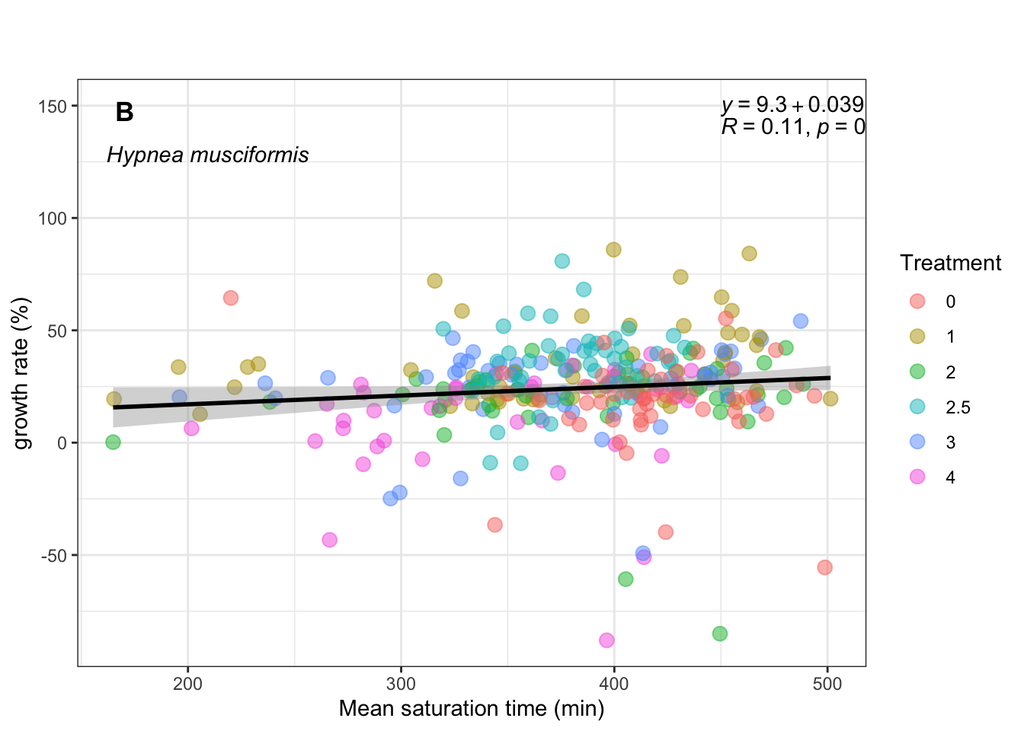

```r
hypnea_growth_irrad_ek_graph <- ggplot(hypnea, aes(x=supersat_total, y=growth_rate)) +
        geom_point(alpha = 0.5, size = 3, aes(color = Treatment), show.legend = TRUE) +
        geom_smooth(method = "lm", col = "black") + theme_bw() +
        labs(title = "B", subtitle = "Hypnea musciformis", x = "Mean saturation time (min)", y = "growth rate (%)") +
        stat_regline_equation(label.x = 450, label.y = 150) + stat_cor(label.x = 450, label.y = 140) +
        theme(plot.title = element_text(face = "bold", vjust = -15, hjust = 0.05),
              plot.subtitle = element_text(face = "italic", vjust = -20, hjust = 0.05))
hypnea_growth_irrad_ek_graph
```

Make a boxplot for publications of the results

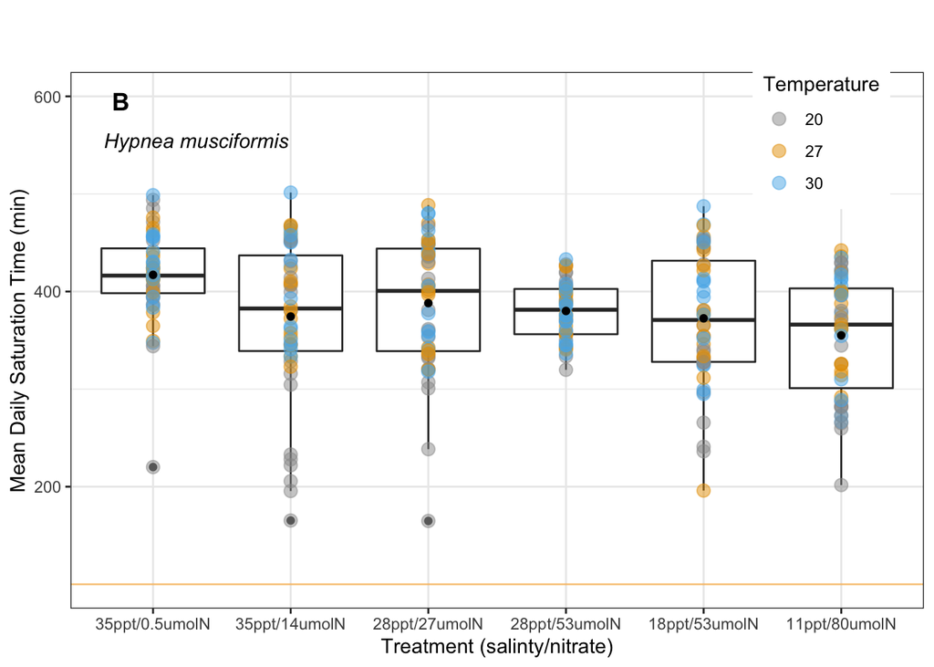

```r
hypnea %>% ggplot(aes(treatment_graph, supersat_total)) +
        geom_boxplot(size=0.5) +
        geom_point(alpha = 0.5, size = 3, aes(color = Temperature), show.legend = TRUE) +
        labs(x="Treatment (salinty/nitrate)", y= "Mean Daily Saturation Time (min)", title= "B", subtitle = "Hypnea musciformis") +
        scale_x_discrete(labels = c("35ppt/0.5umolN", "35ppt/14umolN", "28ppt/27umolN", "28ppt/53umolN", "18ppt/53umolN", "11ppt/80umolN")) +
        ylim(100, 600) + stat_mean() +
        geom_hline(yintercept=100, color = "orange", size = 0.5, alpha = 0.5) +
        scale_color_manual(values = c("#999999", "#E69F00", "#56B4E9")) +
        theme_bw() +
        theme(legend.position = c(0.88,0.88), plot.title = element_text(face = "bold", vjust = -15, hjust = 0.05),
              plot.subtitle = element_text(face = "italic", vjust = -20, hjust = 0.05))
```

```r
hypnea %>% group_by(Treatment) %>% summarise_at(vars(supersat_total), list(mean = mean))
```

```
## # A tibble: 6 × 2
##   Treatment  mean
##   <fct>     <dbl>
## 1 0          417.
## 2 1          374.
## 3 2          388.
## 4 2.5        380.
## 5 3          373.
## 6 4          355.
```

```r
hypnea %>% group_by(Run) %>% summarise_at(vars(supersat_total), list(mean = mean))
```

```
## # A tibble: 8 × 2
##   Run    mean
##   <fct> <dbl>
## 1 1      407.
## 2 2      426.
## 3 3      360.
## 4 3.5    312.
## 5 4      320.
## 6 7      380.
## 7 8      406.
## 8 9      428.
```